# Global Superstore — Performance Analysis (Python)

**ShadowFox Data Analyst Internship — Intermediate Level Submission**

*Customer, Revenue & Profitability Analysis, built end-to-end in Python (pandas + matplotlib)*

### 1. Overview & Dataset

This notebook analyses the "Global Superstore" dataset — a well-known, publicly available retail analytics dataset widely used for business-performance coursework. This copy is an 800-customer, 867-order sample spanning January 2012 – December 2015 across 93 countries, sourced from a public GitHub mirror (`github.com/yannie28/Global-Superstore`).

The brief for this level asks for more than descriptive summaries: identify which customers, products and markets drive revenue and profit, understand repeat-purchase behaviour, and turn the findings into concrete recommendations. Because this is a fixed-size sample rather than a live extract, month-level figures are noisy in places — the analysis leans on quarterly and category/market-level views wherever a finer breakdown wouldn't be reliable, and that limitation is called out directly where it matters.

Everything below — cleaning, exploratory analysis, segmentation, trend analysis, charts, and the final insights — is computed directly from the raw CSV in this notebook. Nothing is pre-aggregated in a spreadsheet first.

```
Raw shape: (1000, 24)
```

|  | Row ID | Order ID | Order Date | Ship Date | Ship Mode | Customer ID | Customer Name | Segment | Postal Code | City | ... | Product ID | Category | Sub-Category | Product Name | Sales | Quantity | Discount | Profit | Shipping Cost | Order Priority |
| --- | --- | --- | --- | --- | --- | --- | --- | --- | --- | --- | --- | --- | --- | --- | --- | --- | --- | --- | --- | --- | --- |
| 0 | 40098 | CA-2014-AB10015140-41954 | 11/11/2014 | 11/13/2014 | First Class | AB-100151402 | Aaron Bergman | Consumer | 73,120.00 | Oklahoma City | ... | TEC-PH-5816 | Technology | Phones | Samsung Convoy 3 | 221.98 | 2 | 0.00 | 62.15 | 40.77 | High |
| 1 | 26341 | IN-2014-JR162107-41675 | 2/5/2014 | 2/7/2014 | Second Class | JR-162107 | Justin Ritter | Corporate | NaN | Wollongong | ... | FUR-CH-5379 | Furniture | Chairs | Novimex Executive Leather Armchair, Black | 3,709.40 | 9 | 0.10 | -288.77 | 923.63 | Critical |
| 2 | 25330 | IN-2014-CR127307-41929 | 10/17/2014 | 10/18/2014 | First Class | CR-127307 | Craig Reiter | Consumer | NaN | Brisbane | ... | TEC-PH-5356 | Technology | Phones | Nokia Smart Phone, with Caller ID | 5,175.17 | 9 | 0.10 | 919.97 | 915.49 | Medium |

3 rows × 24 columns

```
Duplicate rows removed.......................0
Ship-before-order date errors................0
Non-positive Sales rows......................0
Non-positive Quantity rows...................0
Missing values...............................{'Postal Code': np.int64(806)}
Negative-profit rows (kept, flagged).........175 (17.5%)
Whitespace fixes applied.....................0
Final cleaned row count......................1000
```

**Notes:**

- `Postal Code` is missing only for non-US rows — many countries don't share the US postal-code system. It isn't used in any revenue or customer analysis below, so it's left as-is rather than imputed.
- The 175 negative-profit rows are genuine loss-making sales, not data-entry errors (see Section 5 for why) — kept rather than dropped, since removing them would hide a real finding.
- No duplicates, no date-logic errors, no invalid Sales/Quantity — this is a curated public dataset, so cleaning needs were light, but every check was still run and is documented above rather than assumed.

```
Cleaned file written: (1000, 24)
```

## 3. Headline KPIs

```
Total Revenue............$1,710,971
Total Profit.............$288,920
Profit Margin............16.9%
Unique Customers.........800
Avg Order Value..........$1,973.44
Unique Orders............867
```

## 4. Revenue & Profit Trend

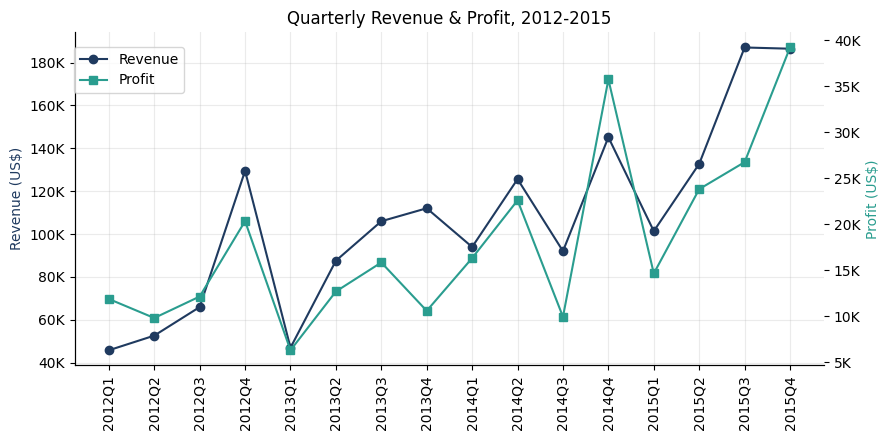

```
Strongest quarter: 2015Q3 ($187,077.86)
Weakest quarter:   2012Q1 ($45,779.40)
```

## 5. Category & Sub-Category Performance

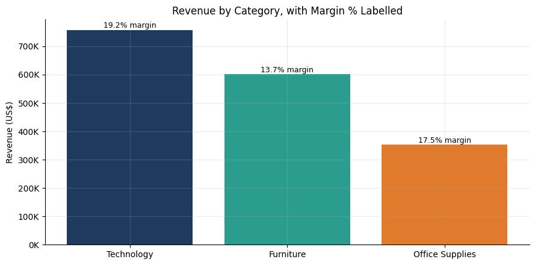

|  | Category | revenue | profit | margin_pct | revenue_share_pct |
| --- | --- | --- | --- | --- | --- |
| 2 | Technology | 756,983.02 | 145,068.68 | 19.16 | 44.24 |
| 0 | Furniture | 601,492.31 | 82,188.95 | 13.66 | 35.16 |
| 1 | Office Supplies | 352,496.14 | 61,662.81 | 17.49 | 20.60 |

|  | Category | Sub-Category | revenue | profit | avg_discount | orders | margin_pct |
| --- | --- | --- | --- | --- | --- | --- | --- |
| 16 | Technology | Phones | 417,939.31 | 75,119.47 | 0.07 | 176 | 17.97 |
| 4 | Office Supplies | Appliances | 289,711.30 | 48,518.99 | 0.09 | 125 | 16.75 |
| 0 | Furniture | Bookcases | 240,688.73 | 45,483.14 | 0.05 | 128 | 18.90 |
| 14 | Technology | Copiers | 231,104.67 | 52,315.19 | 0.04 | 125 | 22.64 |
| 1 | Furniture | Chairs | 179,648.44 | 23,245.88 | 0.12 | 95 | 12.94 |
| 3 | Furniture | Tables | 179,292.88 | 13,051.69 | 0.17 | 85 | 7.28 |
| 15 | Technology | Machines | 71,366.87 | 8,992.06 | 0.11 | 52 | 12.60 |
| 11 | Office Supplies | Storage | 37,592.32 | 4,490.04 | 0.07 | 42 | 11.94 |
| 13 | Technology | Accessories | 36,572.17 | 8,641.96 | 0.07 | 37 | 23.63 |
| 6 | Office Supplies | Binders | 19,751.19 | 7,435.09 | 0.34 | 31 | 37.64 |
| 12 | Office Supplies | Supplies | 2,037.92 | -89.85 | 0.09 | 7 | -4.41 |
| 2 | Furniture | Furnishings | 1,862.26 | 408.24 | 0.13 | 13 | 21.92 |
| 10 | Office Supplies | Paper | 1,816.57 | 806.32 | 0.08 | 29 | 44.39 |
| 5 | Office Supplies | Art | 904.55 | 191.87 | 0.09 | 16 | 21.21 |
| 8 | Office Supplies | Fasteners | 513.44 | 246.47 | 0.00 | 6 | 48.00 |
| 7 | Office Supplies | Envelopes | 114.06 | 42.02 | 0.00 | 2 | 36.84 |
| 9 | Office Supplies | Labels | 54.79 | 21.86 | 0.10 | 6 | 39.90 |

```
Tables — net sub-category result:
  Revenue $179,292.88 | Profit $13,051.69 | Margin 7.3%

Tables — loss-making orders only (subset of the above):
  32 orders | Total loss $-15,421.24 | Avg discount 34.4%
```

Technology leads at 44.2% of revenue and also carries the strongest margin (19.2%) — the business's best category on both counts. Furniture sells a large volume (35.2% of revenue) but converts it to profit least efficiently (13.7% margin), making it the clearest candidate for a pricing or discount-policy review.

At the sub-category level, Phones, Appliances and Bookcases are the strongest revenue drivers. **Tables is the weakest performer by margin** (7.3%, the lowest of any profitable sub-category) — it remains net profitable overall, but its 32 heavily-discounted orders (34.4% average discount) combine for a $15,421 loss on their own, meaning that discounting is being subsidised by Tables' other, healthier sales rather than earning back its own margin. (Being precise about "profitable overall but its discounted tail loses money" matters — an earlier pass at this analysis conflated the two and is corrected here.)

## 6. Discounting & Profitability

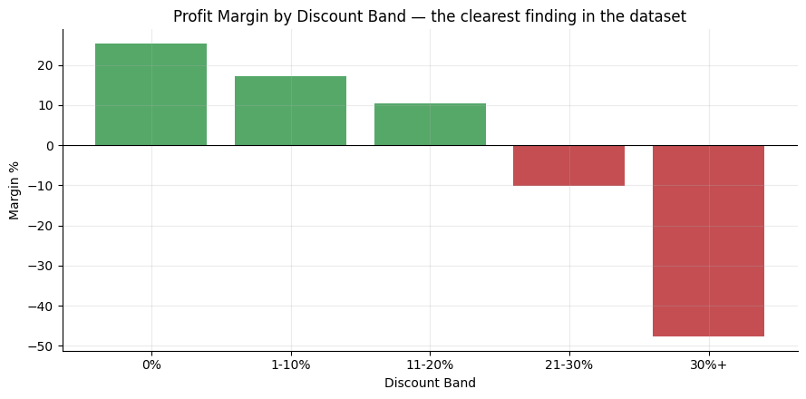

```
Share of all orders that are loss-making: 17.5%
```

|  | discount_band | revenue | profit | margin_pct |
| --- | --- | --- | --- | --- |
| 0 | 0% | 1,034,792.71 | 261,142.04 | 25.24 |
| 1 | 1-10% | 333,031.61 | 57,286.50 | 17.20 |
| 2 | 11-20% | 198,984.22 | 20,946.74 | 10.53 |
| 3 | 21-30% | 48,389.17 | -4,880.05 | -10.09 |
| 4 | 30%+ | 95,773.76 | -45,574.79 | -47.59 |

## 7. Market Performance

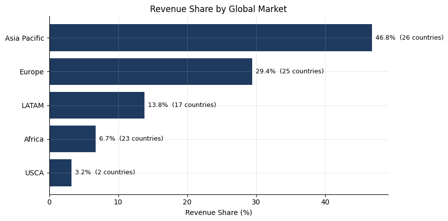

|  | Market | revenue | profit | countries | share_pct | margin_pct |
| --- | --- | --- | --- | --- | --- | --- |
| 1 | Asia Pacific | 800,511.75 | 125,049.47 | 26 | 46.79 | 15.62 |
| 2 | Europe | 503,568.21 | 89,122.08 | 25 | 29.43 | 17.70 |
| 3 | LATAM | 236,263.49 | 34,929.35 | 17 | 13.81 | 14.78 |
| 0 | Africa | 115,205.93 | 27,541.85 | 23 | 6.73 | 23.91 |
| 4 | USCA | 55,422.09 | 12,277.69 | 2 | 3.24 | 22.15 |

Asia Pacific leads at 46.8% of revenue, consistent with it covering the largest number of countries in this sample. USCA has the smallest revenue share here — though with only a handful of countries directly represented in USCA within this sample, that likely reflects lighter sample coverage rather than a genuine demand gap, and would be the first thing to verify against the full dataset before drawing a business conclusion from it.

## 8. Customer Segmentation & Retention

```
Repeat-purchase rate (>1 order): 5.0%  (40 of 800 customers)
```

**Note on segmentation method:** with only 5.0% of customers placing more than one order, a classic 3-axis RFM score (which depends on genuine spread in order *Frequency*) would mostly manufacture artificial differences out of tied values (nearly everyone has Frequency = 1). Instead, customers here are segmented on the two axes that carry real signal: **Recency** (recent vs. lapsed order) and **Monetary** value (high vs. low lifetime spend) — a median split on each, forming four quadrants.

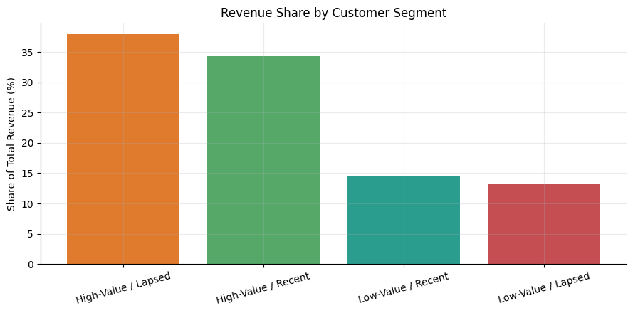

|  | segment | customers | revenue | revenue_share_pct |
| --- | --- | --- | --- | --- |
| 0 | High-Value / Lapsed | 209 | 648,335.73 | 37.89 |
| 1 | High-Value / Recent | 191 | 587,422.48 | 34.33 |
| 3 | Low-Value / Recent | 210 | 248,832.78 | 14.54 |
| 2 | Low-Value / Lapsed | 190 | 226,380.48 | 13.23 |

| Segment | What it means |
| --- | --- |
| **High-Value / Recent** | Big lifetime spend and a recent order — the strongest customers to retain right now. |
| **High-Value / Lapsed** | Spent a lot historically but haven't ordered recently — a win-back priority. |
| **Low-Value / Recent** | Small spend so far, but engaged recently — worth nurturing toward a second order. |
| **Low-Value / Lapsed** | Small spend and inactive — lowest priority for active outreach. |

```
Avg month-over-month retention:        0.6%
Revenue share of top 20% of customers: 38.7%
```

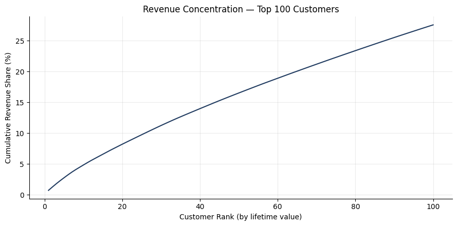

The most important finding in this section isn't the quadrant split itself — it's that only 5.0% of customers in this sample ever placed a second order, and average month-over-month retention is just 0.6% (essentially, almost nobody who bought in one month bought again the next). Read plainly: growth here has been driven almost entirely by acquiring new customers, not by repeat business. Revenue is still concentrated even without much repeat buying: the top 20% of customers by lifetime value drive 38.7% of total revenue, so a relatively small set of large one-time orders matter disproportionately.

## 9. Insights & Recommendations

**Category & product mix**

- Technology leads at 44.2% of revenue and also has the strongest margin (19.2%). Furniture sells well but converts that revenue into profit least efficiently (13.7% margin) — worth a pricing or discount-policy review specifically for that category.
- Tables is the lowest-margin *profitable* sub-category (7.3%): its net result is positive, but its heavily-discounted orders alone (34.4% avg. discount) lose $15,421 combined — the discount policy for this sub-category needs a floor.

**Market performance**

- Asia Pacific is the largest market at 46.8% of revenue. USCA is the smallest by revenue in this sample — worth checking whether that's genuinely lower demand or simply lighter sales coverage.

**Customer behaviour & retention**

- Only 5.0% of customers placed more than one order, and month-over-month retention averages just 0.6% — growth here is almost entirely acquisition-driven, not repeat-business-driven.
- The top 20% of customers by lifetime value still drive 38.7% of revenue — a small number of large one-time orders matter disproportionately.

**Recommended next actions**

1. Introduce a discount floor or approval tier above ~20-30% — that's the exact point where orders flip from profitable to loss-making.
2. Review pricing or bundling for Tables specifically — its discounted-order tail is losing money even though the sub-category overall isn't.
3. Build a genuine repeat-purchase program (post-purchase follow-up, loyalty incentive) — retention, not acquisition, is the biggest untapped lever given a 5% repeat rate.
4. Investigate USCA's low revenue share directly — a coverage gap is a different (and more fixable) problem than a demand gap.
5. Give High-Value/Recent and High-Value/Lapsed segments dedicated account attention — together they hold the large majority of revenue despite being roughly half of customers.
6. Apply Technology's pricing discipline (strongest margin of the three categories) as a benchmark when reviewing Furniture's and Tables' discount policy.

## 10. Methodology Note

This entire analysis — data cleaning and validation, exploratory analysis, category/market/discount breakdowns, customer segmentation (Recency × Monetary quadrants), retention and concentration metrics, all six charts, and the write-up above — was built directly in this notebook using pandas and matplotlib, computed straight from the raw CSV with no spreadsheet step in between. The cleaned dataset produced in Section 2 (`Global_Superstore_Cleaned_by_notebook.csv`) is written out alongside this notebook so the pipeline is fully reproducible end to end.